# Assignment 1

Albert Kaczmarek, h52201551Maciej Kilijański, h12018188Balázs Kiss, h12314734

- Part 1: Data Loading and Inspection
  - 1. Load the Data
  - 2. Inspect the Data
- Part 2: Data Cleaning and Tidying
  - 3. Handle Missing Values in customer_sales
  - 4. Standardize Date Formats
  - 5. Correct data types
  - 6. Resolve inconsistencies
- Part 3: Data Integration with joins
  - 7. Left join
  - 8. Inner join
  - 9. Right join
  - 10. Full Join
- Part 4: Data Manipulation with dplyr
  - 11. Create a Profit and an AgeGroup column
  - 12. Filter and select data
  - 13. Arrange Data
- Part 5: Data Aggregation
  - 14. Group and Summarize
  - 15. Compute cumulative metrics
- Part 6: Data Tidying with tidyr
  - 16. Reshape the data
- Part 7: Data Visualization with ggplot2
  - 17. Create a bar chart
  - 18. Creating a time series plot
  - 19. Creating a scatterplot
- Part 8: Advanced visualization
  - 20. Faceting and Themes
  - 21. Customize Scales and Guides
- Part 9: Additional Analysis with Joins
  - 22. Identify unmatched records
  - 23. Compare Different Joins
- Part 10: Deliverables
  - Data clearning
  - Joins

#### Setup:

Loading necessary libraries.

```r
library("tidyverse")
library("ggplot2")
library("readr")
library("lubridate")
library("dplyr")
library("ggplot2")
```

## Part 1: Data Loading and Inspection

### 1. Load the Data

```r
customer_sales <- read_csv("customer_sales.csv")
customer_info <- read_csv("customer_info.csv")
product_info <- read_csv("product_info.csv")
supplier_info <- read_csv("supplier_info.csv")
```

### 2. Inspect the Data

```r
glimpse(customer_sales)
```

```
## Rows: 80
## Columns: 8
## $ OrderID    <dbl> 1001, 1002, 1003, 1004, 1005, 1006, 1007, 1008, 1009, 1010,…
## $ Date       <chr> "03/02/2023", "10/02/2023", "30/01/2023", "2023-02-19", "02…
## $ CustomerID <chr> "C001", "C008", "C008", "C010", "C008", "C018", "C009", "C0…
## $ ProductID  <chr> "P114", "P102", "P108", "P106", "P108", "P103", "P101", "P1…
## $ Quantity   <dbl> 3, NA, 4, 5, 2, 2, 4, 2, 1, 4, 3, 1, 5, 3, 4, 2, 5, 5, 2, N…
## $ UnitPrice  <dbl> 600, 700, 300, 200, 300, 300, 100, -600, 500, -800, 400, 40…
## $ TotalPrice <dbl> NA, NA, 1200, 1000, 600, 600, 400, -1200, 500, -3200, 1200,…
## $ Region     <chr> "West", "East", "North", "North", "South", "South", "North"…
```

```r
summary(customer_sales)
```

```
##     OrderID         Date            CustomerID         ProductID
##  Min.   :1001   Length:80          Length:80          Length:80
##  1st Qu.:1021   Class :character   Class :character   Class :character
##  Median :1040   Mode  :character   Mode  :character   Mode  :character
##  Mean   :1040
##  3rd Qu.:1060
##  Max.   :1080
##
##     Quantity      UnitPrice      TotalPrice       Region
##  Min.   :1.00   Min.   :-800   Min.   :-3520   Length:80
##  1st Qu.:2.00   1st Qu.: 200   1st Qu.:  500   Class :character
##  Median :3.00   Median : 400   Median : 1200   Mode  :character
##  Mean   :3.08   Mean   : 412   Mean   : 1176
##  3rd Qu.:4.00   3rd Qu.: 650   3rd Qu.: 2075
##  Max.   :5.00   Max.   : 800   Max.   : 4000
##  NA's   :5      NA's   :5      NA's   :14
```

```r
glimpse(customer_info)
```

```
## Rows: 20
## Columns: 6
## $ CustomerID <chr> "C001", "C002", "C003", "C004", "C005", "C006", "C007", "C0…
## $ Name       <chr> "Alice Smith", "Bob Johnson", "Charlie Lee", "Diana King", …
## $ Email      <chr> "alice@example.com", "bob@example.com", "charlie@example.co…
## $ Age        <dbl> 42, 60, 44, 40, 24, 31, 21, 37, 23, 42, 27, 20, 30, 56, 30,…
## $ Gender     <chr> "Male", "Male", "Female", "Male", "Male", "Female", "Female…
## $ Region     <chr> "West", "West", "North", "South", "East", "South", "South",…
```

```r
summary(customer_info)
```

```
##   CustomerID            Name              Email                Age
##  Length:20          Length:20          Length:20          Min.   :20.00
##  Class :character   Class :character   Class :character   1st Qu.:29.25
##  Mode  :character   Mode  :character   Mode  :character   Median :34.00
##                                                           Mean   :36.15
##                                                           3rd Qu.:42.00
##                                                           Max.   :60.00
##     Gender             Region
##  Length:20          Length:20
##  Class :character   Class :character
##  Mode  :character   Mode  :character
##
##
##
```

```r
glimpse(product_info)
```

```
## Rows: 20
## Columns: 4
## $ ProductID  <chr> "P101", "P102", "P103", "P104", "P105", "P106", "P107", "P1…
## $ Product    <chr> "Laptop", "Chair", "Desk", "Smartphone", "Monitor", "Table"…
## $ Category   <chr> "Furniture", "Furniture", "Electronics", "Electronics", "Fu…
## $ SupplierID <chr> "S006", "S006", "S003", "S003", "S001", "S001", "S006", "S0…
```

```r
summary(product_info)
```

```
##   ProductID           Product            Category          SupplierID
##  Length:20          Length:20          Length:20          Length:20
##  Class :character   Class :character   Class :character   Class :character
##  Mode  :character   Mode  :character   Mode  :character   Mode  :character
```

```r
glimpse(supplier_info)
```

```
## Rows: 6
## Columns: 4
## $ SupplierID   <chr> "S001", "S002", "S003", "S004", "S005", "S006"
## $ SupplierName <chr> "TechCorp", "FurniCo", "WoodWorks", "GadgetHub", "HomeEss…
## $ ContactEmail <chr> "contact@techcorp.com", "contact@furnico.com", "contact@w…
## $ Region       <chr> "North", "South", "West", "East", "East", "North"
```

```r
summary(supplier_info)
```

```
##   SupplierID        SupplierName       ContactEmail          Region
##  Length:6           Length:6           Length:6           Length:6
##  Class :character   Class :character   Class :character   Class :character
##  Mode  :character   Mode  :character   Mode  :character   Mode  :character
```

## Part 2: Data Cleaning and Tidying

### 3. Handle Missing Values in customer_sales

Identify rows with missing Quantity, UnitPrice, or TotalPrice:

```r
customer_sales |>
  filter(is.na(Quantity) | is.na(UnitPrice) | is.na(TotalPrice))
```

```
## # A tibble: 15 × 8
##    OrderID Date       CustomerID ProductID Quantity UnitPrice TotalPrice Region
##      <dbl> <chr>      <chr>      <chr>        <dbl>     <dbl>      <dbl> <chr>
##  1    1001 03/02/2023 C001       P114             3       600         NA West
##  2    1002 10/02/2023 C008       P102            NA       700         NA East
##  3    1012 2023-01-25 C001       P112             1       400         NA West
##  4    1020 27-Jän-23  C020       P116            NA       500         NA West
##  5    1033 28/03/2023 C020       P112             3        NA         NA South
##  6    1036 30-Mär-23  <NA>       P119             1        NA         NA South
##  7    1039 2023-03-01 C003       P115             1        NA         NA East
##  8    1047 2023-02-09 C008       P109            NA       500         NA South
##  9    1062 2023-03-19 C001       P115            NA       600         NA North
## 10    1063 01-07-2023 C002       P116            NA       800         NA East
## 11    1066 14/01/2023 <NA>       P101             1       600         NA West
## 12    1067 2023-03-31 <NA>       P117             3        NA        880 East
## 13    1072 01/02/2023 C012       P105             4       300         NA South
## 14    1078 25-Jän-23  C006       P100             1       400         NA North
## 15    1079 10-Feb-23  C016       P100             5        NA         NA South
```

Identifying rows with available Quantity, UnitPrice, but no TotalPrice

```r
customer_sales |>
  filter(!is.na(Quantity) & !is.na(UnitPrice) & is.na(TotalPrice))
```

```
## # A tibble: 5 × 8
##   OrderID Date       CustomerID ProductID Quantity UnitPrice TotalPrice Region
##     <dbl> <chr>      <chr>      <chr>        <dbl>     <dbl>      <dbl> <chr>
## 1    1001 03/02/2023 C001       P114             3       600         NA West
## 2    1012 2023-01-25 C001       P112             1       400         NA West
## 3    1066 14/01/2023 <NA>       P101             1       600         NA West
## 4    1072 01/02/2023 C012       P105             4       300         NA South
## 5    1078 25-Jän-23  C006       P100             1       400         NA North
```

> There are 5 such values

Correcting these values:, using `mutate()`. If `TotalPrice` is missing, it will be calculated by multiplicating $Quantity\cdot UnitPrice$.

```r
customer_sales <- customer_sales |>
  mutate(TotalPrice = ifelse(!is.na(Quantity) & !is.na(UnitPrice & is.na(TotalPrice)),
                             Quantity * UnitPrice,
                             TotalPrice))
```

Filtering rows where `Quantity` and `TotalPrice` are available, but `UnitPrice` is missing:

```r
customer_sales |>
  filter(!is.na(Quantity) & is.na(UnitPrice) & !is.na(TotalPrice))
```

```
## # A tibble: 0 × 8
## # ℹ 8 variables: OrderID <dbl>, Date <chr>, CustomerID <chr>, ProductID <chr>,
## #   Quantity <dbl>, UnitPrice <dbl>, TotalPrice <dbl>, Region <chr>
```

> There are no such rows

We do not need to fill in missing `UnitPrice`.

Filtering rows where Unit Price and TotalPrice are available, Quantity is missing:

```r
customer_sales |>
  filter(is.na(Quantity) & !is.na(UnitPrice) & !is.na(TotalPrice))
```

```
## # A tibble: 0 × 8
## # ℹ 8 variables: OrderID <dbl>, Date <chr>, CustomerID <chr>, ProductID <chr>,
## #   Quantity <dbl>, UnitPrice <dbl>, TotalPrice <dbl>, Region <chr>
```

> There are no such rows

We do not need to fill in missing `Quantity`.

> The rows with remaining NA values in 2 or 3 of the 3 columns are removed since their values cannot be inferred:

```r
customer_sales <- customer_sales |>
  filter(!(is.na(Quantity) | is.na(UnitPrice) | is.na(TotalPrice)))
```

Only 70 rows are kept from the original 80:

- 10 rows have 2 out of 3 crucial values missing, making them impossible to inferr.

### 4. Standardize Date Formats

Substituting values which parse_date_time() doesn’t recognize:

```r
customer_sales$Date <- gsub("Jän", "Jan", customer_sales$Date)
```

After the values have been cleaned, we can parse the date column:

```r
customer_sales$Date <- parse_date_time(
  customer_sales$Date,
  orders = c("ymd", "dmy", "mdy", "Ymd", "dmY", "mdY", "dMY"),
  locale = "de_DE" # This helps parse German month abbreviations
)
```

Let’s see the result (`head(,3)` will display 3 top rows):

```r
head(customer_sales,3)
```

```
## # A tibble: 3 × 8
##   OrderID Date                CustomerID ProductID Quantity UnitPrice TotalPrice
##     <dbl> <dttm>              <chr>      <chr>        <dbl>     <dbl>      <dbl>
## 1    1001 2023-02-03 00:00:00 C001       P114             3       600       1800
## 2    1003 2023-01-30 00:00:00 C008       P108             4       300       1200
## 3    1004 2023-02-19 00:00:00 C010       P106             5       200       1000
## # ℹ 1 more variable: Region <chr>
```

Correcting the dates which weren’t interpreted for 2023 but should’ve been e.g. `30-03-23` was parsed as `2030-03-23` instead of `2023-03-30`. We perform this in several steps:

> Splitting the data frame into 2 - 2023 and non-2023 (wrong) dates 1. Filter observations where Date is for 2023 or not available

```r
df_2023 <- customer_sales |>
  filter(year(Date) == 2023 | is.na(Date)) |> print()
```

```
## # A tibble: 54 × 8
##    OrderID Date                CustomerID ProductID Quantity UnitPrice
##      <dbl> <dttm>              <chr>      <chr>        <dbl>     <dbl>
##  1    1001 2023-02-03 00:00:00 C001       P114             3       600
##  2    1003 2023-01-30 00:00:00 C008       P108             4       300
##  3    1004 2023-02-19 00:00:00 C010       P106             5       200
##  4    1005 2023-02-07 00:00:00 C008       P108             2       300
##  5    1006 2023-01-13 00:00:00 C018       P103             2       300
##  6    1007 2023-01-22 00:00:00 C009       P101             4       100
##  7    1008 2023-03-08 00:00:00 C007       P111             2      -600
##  8    1009 2023-03-08 00:00:00 C007       P108             1       500
##  9    1010 2023-01-16 00:00:00 C010       P110             4      -800
## 10    1011 2023-03-20 00:00:00 C011       P106             3       400
## # ℹ 44 more rows
## # ℹ 2 more variables: TotalPrice <dbl>, Region <chr>
```

2. Filter observations where Date is NOT for 2023

```r
df_filtered <- customer_sales |>
  filter(year(Date) != 2023)  |> print()
```

```
## # A tibble: 16 × 8
##    OrderID Date                CustomerID ProductID Quantity UnitPrice
##      <dbl> <dttm>              <chr>      <chr>        <dbl>     <dbl>
##  1    1021 2031-01-23 00:00:00 C009       P111             2       200
##  2    1022 2021-02-23 00:00:00 C009       P102             1       700
##  3    1024 2020-02-23 00:00:00 C014       P114             4       300
##  4    1025 2030-03-23 00:00:00 C014       P102             3       600
##  5    1031 2013-03-23 00:00:00 C007       P107             4       300
##  6    1037 2025-01-23 00:00:00 C005       P119             3       200
##  7    1038 2022-02-23 00:00:00 C020       P108             4       800
##  8    1041 2010-03-23 00:00:00 C001       P106             4      -800
##  9    1043 2021-02-23 00:00:00 C004       P116             5       100
## 10    1052 2007-01-23 00:00:00 C007       P118             1       300
## 11    1054 2013-01-23 00:00:00 C016       P112             3       500
## 12    1057 2021-02-23 00:00:00 C008       P115             2       400
## 13    1065 2028-03-23 00:00:00 C002       P120             5       400
## 14    1069 2031-01-23 00:00:00 C018       P114             2       800
## 15    1075 2014-01-23 00:00:00 C006       P118             3       300
## 16    1078 2025-01-23 00:00:00 C006       P100             1       400
## # ℹ 2 more variables: TotalPrice <dbl>, Region <chr>
```

3. Converting dates from YYYY-MM-DD to YY-MM-DD

```r
df_filtered <- df_filtered |>
  mutate(Date = format(Date, "%y-%m-%d")) |> print()
```

```
## # A tibble: 16 × 8
##    OrderID Date     CustomerID ProductID Quantity UnitPrice TotalPrice Region
##      <dbl> <chr>    <chr>      <chr>        <dbl>     <dbl>      <dbl> <chr>
##  1    1021 31-01-23 C009       P111             2       200        400 East
##  2    1022 21-02-23 C009       P102             1       700        700 East
##  3    1024 20-02-23 C014       P114             4       300       1200 North
##  4    1025 30-03-23 C014       P102             3       600       1800 West
##  5    1031 13-03-23 C007       P107             4       300       1200 North
##  6    1037 25-01-23 C005       P119             3       200        600 East
##  7    1038 22-02-23 C020       P108             4       800       3200 South
##  8    1041 10-03-23 C001       P106             4      -800      -3200 West
##  9    1043 21-02-23 C004       P116             5       100        500 North
## 10    1052 07-01-23 C007       P118             1       300        300 North
## 11    1054 13-01-23 C016       P112             3       500       1500 West
## 12    1057 21-02-23 C008       P115             2       400        800 North
## 13    1065 28-03-23 C002       P120             5       400       2000 West
## 14    1069 31-01-23 C018       P114             2       800       1600 South
## 15    1075 14-01-23 C006       P118             3       300        900 West
## 16    1078 25-01-23 C006       P100             1       400        400 North
```

4. Converting all non-2023 values to 2023 (Switching YY with DD)

```r
df_filtered <- df_filtered |>
  mutate(Date = dmy(Date)) |> print()
```

```
## # A tibble: 16 × 8
##    OrderID Date       CustomerID ProductID Quantity UnitPrice TotalPrice Region
##      <dbl> <date>     <chr>      <chr>        <dbl>     <dbl>      <dbl> <chr>
##  1    1021 2023-01-31 C009       P111             2       200        400 East
##  2    1022 2023-02-21 C009       P102             1       700        700 East
##  3    1024 2023-02-20 C014       P114             4       300       1200 North
##  4    1025 2023-03-30 C014       P102             3       600       1800 West
##  5    1031 2023-03-13 C007       P107             4       300       1200 North
##  6    1037 2023-01-25 C005       P119             3       200        600 East
##  7    1038 2023-02-22 C020       P108             4       800       3200 South
##  8    1041 2023-03-10 C001       P106             4      -800      -3200 West
##  9    1043 2023-02-21 C004       P116             5       100        500 North
## 10    1052 2023-01-07 C007       P118             1       300        300 North
## 11    1054 2023-01-13 C016       P112             3       500       1500 West
## 12    1057 2023-02-21 C008       P115             2       400        800 North
## 13    1065 2023-03-28 C002       P120             5       400       2000 West
## 14    1069 2023-01-31 C018       P114             2       800       1600 South
## 15    1075 2023-01-14 C006       P118             3       300        900 West
## 16    1078 2023-01-25 C006       P100             1       400        400 North
```

5. Converting them back to standard format (YYYY-MM-DD)
6. Combining the 2 data frames back together

```r
customer_sales <- bind_rows(df_2023, df_filtered) |> print()
```

```
## # A tibble: 70 × 8
##    OrderID Date                CustomerID ProductID Quantity UnitPrice
##      <dbl> <dttm>              <chr>      <chr>        <dbl>     <dbl>
##  1    1001 2023-02-03 00:00:00 C001       P114             3       600
##  2    1003 2023-01-30 00:00:00 C008       P108             4       300
##  3    1004 2023-02-19 00:00:00 C010       P106             5       200
##  4    1005 2023-02-07 00:00:00 C008       P108             2       300
##  5    1006 2023-01-13 00:00:00 C018       P103             2       300
##  6    1007 2023-01-22 00:00:00 C009       P101             4       100
##  7    1008 2023-03-08 00:00:00 C007       P111             2      -600
##  8    1009 2023-03-08 00:00:00 C007       P108             1       500
##  9    1010 2023-01-16 00:00:00 C010       P110             4      -800
## 10    1011 2023-03-20 00:00:00 C011       P106             3       400
## # ℹ 60 more rows
## # ℹ 2 more variables: TotalPrice <dbl>, Region <chr>
```

7. Checking if all dates are for 2023

```r
customer_sales |>
  filter(year(Date) != 2023)
```

```
## # A tibble: 0 × 8
## # ℹ 8 variables: OrderID <dbl>, Date <dttm>, CustomerID <chr>, ProductID <chr>,
## #   Quantity <dbl>, UnitPrice <dbl>, TotalPrice <dbl>, Region <chr>
```

As we can see, the returned tibble is empty, meaning all dates are correct. We can remove the 2 separate parts as we don’t need them anymore

```r
rm(df_2023, df_filtered)
```

### 5. Correct data types

Converting OrderID, Quantity, UnitPrice and TotalPrice columns from dbl to integer.

```r
customer_sales$OrderID <- as.integer(customer_sales$OrderID)
customer_sales$Date <- as.Date(customer_sales$Date)
customer_sales$Quantity <- as.integer(customer_sales$Quantity)
customer_sales$UnitPrice <- as.integer(customer_sales$UnitPrice)
customer_sales$TotalPrice <- as.integer(customer_sales$TotalPrice)
```

Let’s see the result:

```r
head(customer_sales,3)
```

```
## # A tibble: 3 × 8
##   OrderID Date       CustomerID ProductID Quantity UnitPrice TotalPrice Region
##     <int> <date>     <chr>      <chr>        <int>     <int>      <int> <chr>
## 1    1001 2023-02-03 C001       P114             3       600       1800 West
## 2    1003 2023-01-30 C008       P108             4       300       1200 North
## 3    1004 2023-02-19 C010       P106             5       200       1000 North
```

All formats are correct

### 6. Resolve inconsistencies

Correct any discrepancies found + Correcting negative values

```r
customer_sales$UnitPrice <- abs(customer_sales$UnitPrice)
customer_sales$TotalPrice <- abs(customer_sales$TotalPrice)
```

Verify that TotalPrice equals $Quantity \cdot UnitPrice$ for all rows

```r
all(customer_sales$TotalPrice == customer_sales$Quantity * customer_sales$UnitPrice)
```

```
## [1] TRUE
```

> All values correspond with each other

## Part 3: Data Integration with joins

### 7. Left join

Perform a `left_join()` of `customer_sales` with `customer_info` on `CustomerID`

```r
customer_sales_enriched <- left_join(customer_sales, customer_info, by = "CustomerID")
```

Identify how many rows have missing customer information after the join

```r
customer_sales_enriched |> filter(is.na(Name))
```

```
## # A tibble: 3 × 13
##   OrderID Date       CustomerID ProductID Quantity UnitPrice TotalPrice Region.x
##     <int> <date>     <chr>      <chr>        <int>     <int>      <int> <chr>
## 1    1035 2023-01-23 <NA>       P105             2       600       1200 South
## 2    1048 2023-02-20 <NA>       P110             2       300        600 West
## 3    1066 2023-01-14 <NA>       P101             1       600        600 West
## # ℹ 5 more variables: Name <chr>, Email <chr>, Age <dbl>, Gender <chr>,
## #   Region.y <chr>
```

> There are 3 observations with missing customer information

### 8. Inner join

Perform a `inner_join()` of `customer_sales_enriched` with `product_info` on `ProductID`

```r
customer_sales_enriched <- inner_join(
  customer_sales_enriched, product_info, by = "ProductID"
  )
```

Determine the number of rows in the resulting dataset

```r
glimpse(customer_sales_enriched)
```

```
## Rows: 67
## Columns: 16
## $ OrderID    <int> 1001, 1003, 1004, 1005, 1006, 1007, 1008, 1009, 1010, 1011,…
## $ Date       <date> 2023-02-03, 2023-01-30, 2023-02-19, 2023-02-07, 2023-01-13…
## $ CustomerID <chr> "C001", "C008", "C010", "C008", "C018", "C009", "C007", "C0…
## $ ProductID  <chr> "P114", "P108", "P106", "P108", "P103", "P101", "P111", "P1…
## $ Quantity   <int> 3, 4, 5, 2, 2, 4, 2, 1, 4, 3, 1, 5, 3, 2, 5, 5, 2, 3, 3, 3,…
## $ UnitPrice  <int> 600, 300, 200, 300, 300, 100, 600, 500, 800, 400, 400, 500,…
## $ TotalPrice <int> 1800, 1200, 1000, 600, 600, 400, 1200, 500, 3200, 1200, 400…
## $ Region.x   <chr> "West", "North", "North", "South", "South", "North", "North…
## $ Name       <chr> "Alice Smith", "Hannah Scott", "Jane Baker", "Hannah Scott"…
## $ Email      <chr> "alice@example.com", "hannah@example.com", "jane@example.co…
## $ Age        <dbl> 42, 37, 42, 37, 34, 23, 21, 21, 42, 27, 42, 34, 42, 27, 27,…
## $ Gender     <chr> "Male", "Female", "Male", "Female", "Male", "Male", "Female…
## $ Region.y   <chr> "West", "West", "East", "West", "West", "South", "South", "…
## $ Product    <chr> "Router", "Bookshelf", "Table", "Bookshelf", "Desk", "Lapto…
## $ Category   <chr> "Furniture", "Furniture", "Electronics", "Furniture", "Elec…
## $ SupplierID <chr> "S003", "S005", "S001", "S005", "S003", "S006", "S001", "S0…
```

> 67 rows instead of 70 in the previous dataset

### 9. Right join

Perform a `right_join()` of `product_info` with `customer_sales` on `ProductID`

```r
product_info_enriched <- right_join(product_info, customer_sales, by = "ProductID")
```

Identify products that have no sales records

```r
product_info_enriched |>
  filter(is.na(OrderID))
```

```
## # A tibble: 0 × 11
## # ℹ 11 variables: ProductID <chr>, Product <chr>, Category <chr>,
## #   SupplierID <chr>, OrderID <int>, Date <date>, CustomerID <chr>,
## #   Quantity <int>, UnitPrice <int>, TotalPrice <int>, Region <chr>
```

> There is no such product

### 10. Full Join

Perform a `full_join()` of `customer_info` with `customer_sales` on `CustomerID`

```r
customer_info_enriched <- full_join(customer_info, customer_sales, by = "CustomerID")
```

Identify customers who have not made any purchases

```r
customer_info_enriched |>
  filter(is.na(OrderID))
```

```
## # A tibble: 1 × 13
##   CustomerID Name       Email   Age Gender Region.x OrderID Date   ProductID
##   <chr>      <chr>      <chr> <dbl> <chr>  <chr>      <int> <date> <chr>
## 1 C015       Oscar Jon… osca…    30 Male   South         NA NA     <NA>
## # ℹ 4 more variables: Quantity <int>, UnitPrice <int>, TotalPrice <int>,
## #   Region.y <chr>
```

> 1 customer hasn’t made any purchases: Oscar Jones

## Part 4: Data Manipulation with dplyr

### 11. Create a Profit and an AgeGroup column

```r
customer_sales_enriched <- customer_sales_enriched |>
  mutate(Profit = TotalPrice * 0.25,
         AgeGroup = case_when(
           Age < 30 ~ "Under 30",
           Age >= 30 & Age <= 40 ~ "30-40",
           Age > 40 ~ "Over 40"
         ))
```

### 12. Filter and select data

Assuming we want to get info about the customer region, not the sales region, we will use `Region.y`

```r
customer_sales_enriched |>
  filter(Category == "Electronics") |>
  select(OrderID,
         Date,
         CustomerID,
         Name,
         Product,
         Quantity,
         UnitPrice,
         TotalPrice,
         Profit,
         Region.y,
         AgeGroup)
```

```
## # A tibble: 29 × 11
##    OrderID Date       CustomerID Name      Product Quantity UnitPrice TotalPrice
##      <int> <date>     <chr>      <chr>     <chr>      <int>     <int>      <int>
##  1    1004 2023-02-19 C010       Jane Bak… Table          5       200       1000
##  2    1006 2023-01-13 C018       Rachel N… Desk           2       300        600
##  3    1010 2023-01-16 C010       Jane Bak… Printer        4       800       3200
##  4    1011 2023-03-20 C011       Kevin Ca… Table          3       400       1200
##  5    1012 2023-01-25 C001       Alice Sm… Speaker        1       400        400
##  6    1013 2023-02-11 C019       Steve Pa… Smartp…        5       500       2500
##  7    1014 2023-02-04 C010       Jane Bak… Printer        3       700       2100
##  8    1023 2023-03-30 C005       Ethan Br… Sofa           3       300        900
##  9    1027 2023-02-01 C001       Alice Sm… Sofa           3       600       1800
## 10    1028 2023-01-22 C010       Jane Bak… Lamp           4       800       3200
## # ℹ 19 more rows
## # ℹ 3 more variables: Profit <dbl>, Region.y <chr>, AgeGroup <chr>
```

### 13. Arrange Data

Arranging descending by `TotalPrice`:

```r
customer_sales_enriched |>
  arrange(desc(TotalPrice))
```

```
## # A tibble: 67 × 18
##    OrderID Date       CustomerID ProductID Quantity UnitPrice TotalPrice
##      <int> <date>     <chr>      <chr>        <int>     <int>      <int>
##  1    1017 2023-03-23 C011       P111             5       800       4000
##  2    1046 2023-01-25 C005       P118             5       800       4000
##  3    1058 2023-03-24 C007       P104             5       800       4000
##  4    1049 2023-02-12 C018       P116             5       700       3500
##  5    1010 2023-01-16 C010       P110             4       800       3200
##  6    1028 2023-01-22 C010       P116             4       800       3200
##  7    1051 2023-01-07 C006       P101             4       800       3200
##  8    1038 2023-02-22 C020       P108             4       800       3200
##  9    1041 2023-03-10 C001       P106             4       800       3200
## 10    1045 2023-01-04 C001       P107             4       700       2800
## # ℹ 57 more rows
## # ℹ 11 more variables: Region.x <chr>, Name <chr>, Email <chr>, Age <dbl>,
## #   Gender <chr>, Region.y <chr>, Product <chr>, Category <chr>,
## #   SupplierID <chr>, Profit <dbl>, AgeGroup <chr>
```

## Part 5: Data Aggregation

### 14. Group and Summarize

Grouping by `Region.x` (sales region) and `Category`. Then creating a summary of `TotalQuantity`, `TotalPrice` and `AverageProfit`.

```r
customer_sales_enriched |>
  group_by(Region.x, Category) |>
  summarise(TotalQuantity = sum(Quantity),
            TotalPrice = sum(TotalPrice),
            AverageProfit = mean(Profit), .groups = 'keep') |>
            arrange(Region.x, Category)
```

```
## # A tibble: 8 × 5
## # Groups:   Region.x, Category [8]
##   Region.x Category    TotalQuantity TotalPrice AverageProfit
##   <chr>    <chr>               <int>      <int>         <dbl>
## 1 East     Electronics            16       8400          420
## 2 East     Furniture              17       7500          268.
## 3 North    Electronics            28       8800          314.
## 4 North    Furniture              38      19500          443.
## 5 South    Electronics            22       8400          300
## 6 South    Furniture              32      14800          370
## 7 West     Electronics            28      17500          438.
## 8 West     Furniture              28      12600          315
```

### 15. Compute cumulative metrics

Computing `TotalPrice` per `Region.x`, arranged descending by `Region.x`

```r
customer_sales_enriched |>
  group_by(Region.x) |>
  summarise(TotalPrice = sum(TotalPrice)) |>
  arrange(desc(Region.x))
```

```
## # A tibble: 4 × 2
##   Region.x TotalPrice
##   <chr>         <int>
## 1 West          30100
## 2 South         23200
## 3 North         28300
## 4 East          15900
```

## Part 6: Data Tidying with tidyr

### 16. Reshape the data

Creating a wide-format table showing TotalPrice for each Product across different Regions

```r
wide <- customer_sales_enriched |>
  group_by(ProductID, Region.x) |>
  summarise(TotalPrice = sum(TotalPrice)) |>
  pivot_wider(names_from = Region.x, values_from = TotalPrice)
wide
```

```
## # A tibble: 20 × 5
## # Groups:   ProductID [20]
##    ProductID  East North South  West
##    <chr>     <int> <int> <int> <int>
##  1 P101       3200   400  2000   600
##  2 P102        700    NA  2800  1800
##  3 P103        400    NA   600    NA
##  4 P104         NA    NA  2500  4000
##  5 P105         NA    NA  3600    NA
##  6 P106         NA  1000    NA  4400
##  7 P107         NA  1200   200  2800
##  8 P108         NA  1200  3800   500
##  9 P109       2400   500  2200    NA
## 10 P110       3200    NA    NA  2700
## 11 P111        400 10000    NA  1500
## 12 P112       1800    NA    NA  1900
## 13 P113         NA    NA   800    NA
## 14 P114        100  1200  1600  1800
## 15 P115         NA  3600    NA    NA
## 16 P116         NA  3700    NA  3500
## 17 P117         NA    NA  2700  1000
## 18 P118       2900  4300    NA  1600
## 19 P119        600    NA   400    NA
## 20 P120        200  1200    NA  2000
```

> New columns called afrer `Region.x` values. Less rows.

Converting it back to long format

```r
long <- wide |>
  pivot_longer(
    cols = c("East", "North", "South", "West"),
    names_to = 'Region',
    values_to = 'TotalPrice'
  ) |>
  filter(!is.na(TotalPrice))
long
```

```
## # A tibble: 48 × 3
## # Groups:   ProductID [20]
##    ProductID Region TotalPrice
##    <chr>     <chr>       <int>
##  1 P101      East         3200
##  2 P101      North         400
##  3 P101      South        2000
##  4 P101      West          600
##  5 P102      East          700
##  6 P102      South        2800
##  7 P102      West         1800
##  8 P103      East          400
##  9 P103      South         600
## 10 P104      South        2500
## # ℹ 38 more rows
```

> Less columns, back to 48 rows

## Part 7: Data Visualization with ggplot2

### 17. Create a bar chart

Plotting total price for each category on bar chart

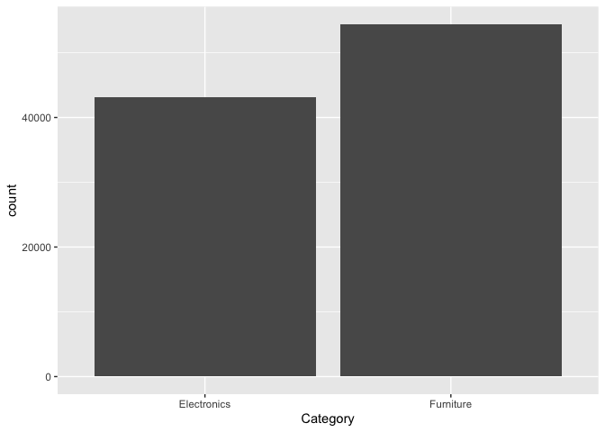

```r
customer_sales_enriched |>
  group_by(Category) |>
  summarise(TotalPrice = sum(TotalPrice)) |>
  ggplot(mapping = aes(x = Category)) +
    geom_bar(aes(weight = TotalPrice))
```

### 18. Creating a time series plot

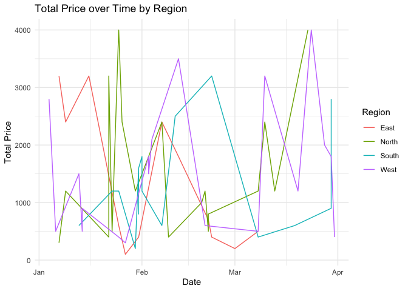

```r
customer_sales_enriched |>
  ggplot(mapping = aes(x = Date, y = TotalPrice, color = Region.x)) +
  geom_line() +
  labs(x = "Date", y = "Total Price", color = "Region", title = "Total Price over Time by Region") +
  theme_minimal()
```

### 19. Creating a scatterplot

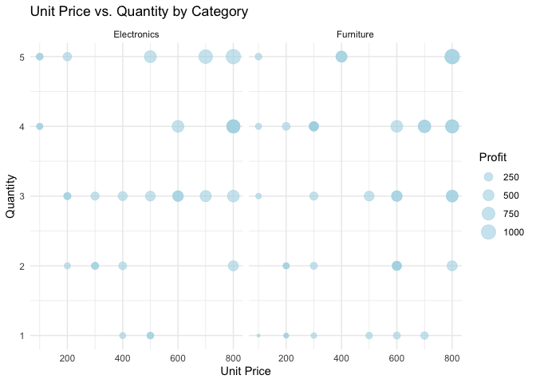

```r
customer_sales_enriched |>
  ggplot(mapping = aes(x = UnitPrice, y = Quantity, size = Profit)) +
  geom_point(alpha = 0.6, color = "lightblue") +  # Use alpha to make points semi-transparent for better visibility
  facet_wrap(~ Category) +   # Facet by Category
  labs(x = "Unit Price", y = "Quantity", size = "Profit", title = "Unit Price vs. Quantity by Category") +
  theme_minimal()
```

## Part 8: Advanced visualization

### 20. Faceting and Themes

Using `facet_wrap()` to create separate plots for each Region.

Applying a custom theme to enhance visual appeal.

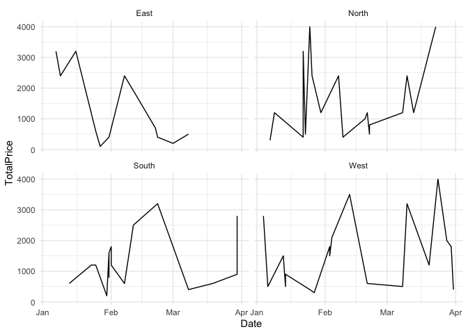

```r
customer_sales_enriched |>
  ggplot(mapping = aes(x = Date, y = TotalPrice)) +
  geom_line() +
  facet_wrap(~ Region.x) +
  theme_minimal()
```

### 21. Customize Scales and Guides

Customizing color scales and legends, using the `color` parameter.

Adding informative axis labels and a descriptive title using `labs()`.

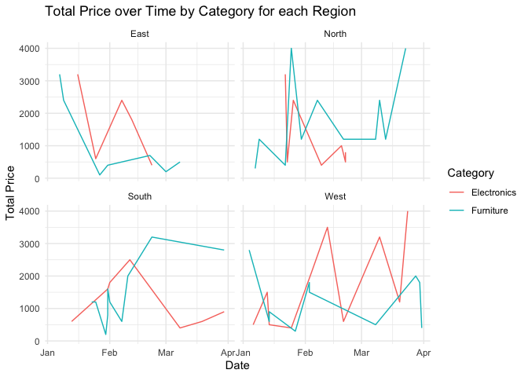

```r
customer_sales_enriched |>
  ggplot(mapping = aes(x = Date, y = TotalPrice, color = Category)) +
  geom_line() +
  facet_wrap(~ Region.x) +
  labs(x = "Date", y = "Total Price", color = "Category", title = "Total Price over Time by Category for each Region") +
  theme_minimal()
```

## Part 9: Additional Analysis with Joins

### 22. Identify unmatched records

After joins, identify any `OrderID` s without matching `CustomerID` s or `ProductID` s.

To do so, we use `filter()` with two conditions and `OR` statement between.

```r
customer_sales_enriched |>
  filter(is.na(CustomerID) | is.na(ProductID))
```

```
## # A tibble: 3 × 18
##   OrderID Date       CustomerID ProductID Quantity UnitPrice TotalPrice Region.x
##     <int> <date>     <chr>      <chr>        <int>     <int>      <int> <chr>
## 1    1035 2023-01-23 <NA>       P105             2       600       1200 South
## 2    1048 2023-02-20 <NA>       P110             2       300        600 West
## 3    1066 2023-01-14 <NA>       P101             1       600        600 West
## # ℹ 10 more variables: Name <chr>, Email <chr>, Age <dbl>, Gender <chr>,
## #   Region.y <chr>, Product <chr>, Category <chr>, SupplierID <chr>,
## #   Profit <dbl>, AgeGroup <chr>
```

> There are 3 rows with missing `CustomerID`
1. Possible reasons for missing `CustomerID`:
   1. Failure to capture customer information upon sale
   2. Customer purchasing online without registering a personal account
   3. Data handling mistakes, wrong / missing data entry
2. Potential implications:
   1. Missing information on customers - less information to base decisions on
   2. Not being able do identify loyal customers - missing opportunity to reward / incentivize
   3. Losing the capability of personalizing and targeting promotions to the individual customer

### 23. Compare Different Joins

Join customer_sales and customer_info using:

1. `left_join`

```r
left <- left_join(customer_sales, customer_info, by = 'CustomerID')
```

2. `inner_join`

```r
inner <- inner_join(customer_sales, customer_info, by = 'CustomerID')
```

3. `right_join`

```r
right <- right_join(customer_sales, customer_info, by = 'CustomerID')
```

4. `full_join`

```r
full <- full_join(customer_sales, customer_info, by = 'CustomerID')
```

Now, lets compare the number of rows received:

```r
nrow(left)
```

```
## [1] 70
```

```r
nrow(inner)
```

```
## [1] 67
```

```r
nrow(right)
```

```
## [1] 68
```

```r
nrow(full)
```

```
## [1] 71
```

Differences between joins. When is each join type appropriate:

| Join type | Method of working | When appropriate? |
| --- | --- | --- |
| Left | Takes the available values in the left data frame and looks for matching values in the right | Appropriate when we want to take the left’s values as a basis and look up matching values for it |
| Inner | Only takes values from the 2 data frames where there are matching pairs | Appropriate when we only want the intersection of the 2 data frames |
| Right | The inverse of left: it takes the available values in the right data frame and looks for matching values in the left | Appropriate when we want to take the right’s values as a basis and look up matching values for it in the left |
| Full | Joins the 2 data frames regardless of matching pairs. The resulting data frame includes all of the 2 data frame’s values | Appropriate when we want to combine the values from 2 tables without leaving out any of the values in the join |

## Part 10: Deliverables

### Data clearning

Our data clearing process started with importing necessary libraries to `R`. These included `dplyr`, `tidyverse`, `lubridate` and `readr`.

Then, data was imported from csv files using the `read_csv` command.